# Exploratory Analysis of World University Rankings Dataset

Greg Mundy

March 16, 2016

## Overview

This document is an exploratory analysis of the [World University Rankings](https://www.kaggle.com/mylesoneill/world-university-rankings) dataset hosted on [Kaggle](http://www.kaggle.com). The dataset contains rankings from three different sources, namely: [The Times Higher Education World University Rankings](https://www.timeshighereducation.com/world-university-rankings), the [Academic Ranking of World Universities](http://www.shanghairanking.com/) (referred to as the Shanghai Ranking), and the [Center for World University Rankings](http://cwur.org/).

In addition to the rankings from the three sources, the dataset also contains the following supplementary data: - [Educational attainment](http://datatopics.worldbank.org/Education/wDataQuery/QProjections.aspx) around the world extracted from the World Bank. -[Public and private direct expenditure on education across nations](http://nces.ed.gov/programs/digest/d14/tables/dt14_605.20.asp) from the National Center for Education Statistics. - A lookup table for university against country extracted from the Times Higher Education World Rankings data.

## Load and Inspect Data

The initial step of the analysis is to load the data into dataframes for examination. Note that the **dplyr** and **tidyr** libraries are loaded in order to aid in the exploration.

```r
# Load dplyr library
library(dplyr)

# Load the tidyr library
library(tidyr)
```

```r
# Establish working directory
setwd("~/Development/datasets/world-university-ranking/")

# Load Times data
TIMES <- tbl_df(read.csv("timesData.csv"))

# Load Shanghai data
SHANGHAI <- tbl_df(read.csv("shanghaiData.csv"))

# Load CWUR data
CWUR <- tbl_df(read.csv("cwurData.csv"))

# Load education attainment supplementary data
ATTAINMENT <- tbl_df(read.csv("educational_attainment_supplementary_data.csv"))

# Load education expenditure supplementary data
EXPENDITURE <- tbl_df(read.csv("education_expenditure_supplementary_data.csv"))

# Load University to Country lookup table
LUT <- tbl_df(read.csv("school_and_country_table.csv"))
```

Brief summaries of the three reports are generated in order to determine how the data is organize. The fact that each organization utilized different methods for ranking the universities is evident. It is also noted that some datasets contain more data than others. The Shanghai data contains 4897 observations and begins in 2005, the Times data contains 2603 observations and begins in 2011, while the CWUR data contains 2200 observations and begins in 2012.

```r
# Summarize Times Data
glimpse(TIMES)
```

```
## Observations: 2,603
## Variables: 14
## $ world_rank             (fctr) 1, 2, 3, 4, 5, 6, 6, 8, 9, 10, 11, 12,...
## $ university_name        (fctr) Harvard University, California Institu...
## $ country                (fctr) United States of America, United State...
## $ teaching               (dbl) 99.7, 97.7, 97.8, 98.3, 90.9, 90.5, 88....
## $ international          (fctr) 72.4, 54.6, 82.3, 29.5, 70.3, 77.7, 77...
## $ research               (dbl) 98.7, 98.0, 91.4, 98.1, 95.4, 94.1, 93....
## $ citations              (dbl) 98.8, 99.9, 99.9, 99.2, 99.9, 94.0, 95....
## $ income                 (fctr) 34.5, 83.7, 87.5, 64.3, -, 57.0, 73.5,...
## $ total_score            (fctr) 96.1, 96.0, 95.6, 94.3, 94.2, 91.2, 91...
## $ num_students           (fctr) 20,152, 2,243, 11,074, 15,596, 7,929, ...
## $ student_staff_ratio    (dbl) 8.9, 6.9, 9.0, 7.8, 8.4, 11.8, 11.6, 16...
## $ international_students (fctr) 25%, 27%, 33%, 22%, 27%, 34%, 34%, 15%...
## $ female_male_ratio      (fctr) , 33 : 67, 37 : 63, 42 : 58, 45 : 55, ...
## $ year                   (int) 2011, 2011, 2011, 2011, 2011, 2011, 201...
```

```r
# Summarize Shanghai Data
glimpse(SHANGHAI)
```

```
## Observations: 4,897
## Variables: 11
## $ world_rank      (fctr) 1, 2, 3, 4, 5, 6, 7, 8, 9, 10, 11, 12, 13, 14...
## $ university_name (fctr) Harvard University, University of Cambridge, ...
## $ national_rank   (fctr) 1, 1, 2, 3, 4, 5, 6, 7, 8, 2, 9, 10, 11, 12, ...
## $ total_score     (dbl) 100.0, 73.6, 73.4, 72.8, 70.1, 67.1, 62.3, 60....
## $ alumni          (dbl) 100.0, 99.8, 41.1, 71.8, 74.0, 59.2, 79.4, 63....
## $ award           (dbl) 100.0, 93.4, 72.2, 76.0, 80.6, 68.6, 60.6, 76....
## $ hici            (dbl) 100.0, 53.3, 88.5, 69.4, 66.7, 59.8, 56.1, 60....
## $ ns              (dbl) 100.0, 56.6, 70.9, 73.9, 65.8, 65.8, 54.2, 48....
## $ pub             (dbl) 100.0, 70.9, 72.3, 72.2, 64.3, 52.5, 69.5, 48....
## $ pcp             (dbl) 72.4, 66.9, 65.0, 52.7, 53.0, 100.0, 45.4, 59....
## $ year            (int) 2005, 2005, 2005, 2005, 2005, 2005, 2005, 2005...
```

```r
# Summarize CWUR Data
glimpse(CWUR)
```

```
## Observations: 2,200
## Variables: 14
## $ world_rank           (int) 1, 2, 3, 4, 5, 6, 7, 8, 9, 10, 11, 12, 13...
## $ institution          (fctr) Harvard University, Massachusetts Instit...
## $ country              (fctr) USA, USA, USA, United Kingdom, USA, USA,...
## $ national_rank        (int) 1, 2, 3, 1, 4, 5, 2, 6, 7, 8, 9, 10, 11, ...
## $ quality_of_education (int) 7, 9, 17, 10, 2, 8, 13, 14, 23, 16, 15, 2...
## $ alumni_employment    (int) 9, 17, 11, 24, 29, 14, 28, 31, 21, 52, 26...
## $ quality_of_faculty   (int) 1, 3, 5, 4, 7, 2, 9, 12, 10, 6, 8, 14, 24...
## $ publications         (int) 1, 12, 4, 16, 37, 53, 15, 14, 13, 6, 34, ...
## $ influence            (int) 1, 4, 2, 16, 22, 33, 13, 6, 12, 5, 20, 21...
## $ citations            (int) 1, 4, 2, 11, 22, 26, 19, 15, 14, 3, 28, 1...
## $ broad_impact         (int) NA, NA, NA, NA, NA, NA, NA, NA, NA, NA, N...
## $ patents              (int) 5, 1, 15, 50, 18, 101, 26, 66, 5, 16, 101...
## $ score                (dbl) 100.00, 91.67, 89.50, 86.17, 85.21, 82.50...
## $ year                 (int) 2012, 2012, 2012, 2012, 2012, 2012, 2012,...
```

## How Different are the Rankings?

One question of interest that should be answered in the exploratory analysis is how different the outcomes of the three rankings truly are given the different methodologies. To answer this question, the first step will be to perform some preliminary tidying of the data.

```r
# Extract the only common elements from the three datasets, namely ranking and
# institution.
times_ranking <- select(TIMES, world_rank, university_name, year)
shanghai_ranking <- select(SHANGHAI, world_rank, university_name, year)
cwur_ranking <- select(CWUR, world_rank, institution, year)

# Convert years to factor for all
times_ranking$year <- factor(times_ranking$year)
shanghai_ranking$year <- factor(shanghai_ranking$year)
cwur_ranking$year <- factor(cwur_ranking$year)

# Convert world_rank of CWUR to factor for consistency
cwur_ranking$world_rank <- factor(cwur_ranking$world_rank)

# Find levels for each reports to determine years
levels(times_ranking$year)
```

```
## [1] "2011" "2012" "2013" "2014" "2015" "2016"
```

```r
levels(shanghai_ranking$year)
```

```
##  [1] "2005" "2006" "2007" "2008" "2009" "2010" "2011" "2012" "2013" "2014"
## [11] "2015"
```

```r
levels(cwur_ranking$year)
```

```
## [1] "2012" "2013" "2014" "2015"
```

By looking at the year levels for the three reports, it is observed that the data intersects at 2012 - 2015. To ensure that the comparisons are meaningful, the observations for each report are narrowed down to years in that range.

```r
times_ranking <- filter(times_ranking, year == "2012" | year == "2013" | year == "2014" | year == "2015")

shanghai_ranking <- filter(shanghai_ranking, year == "2012" | year == "2013" | year == "2014" | year == "2015")
cwur_ranking <- filter(cwur_ranking, year == "2012" | year == "2013" | year == "2014" | year == "2015")
```

A look at the Top 10 universities in 2012 reveals some interesting facts about the data:

```r
# Top 10 Universities in 2012 accordinf to Times
head(times_ranking, 10)
```

```
## Source: local data frame [10 x 3]
##
##    world_rank                       university_name   year
##        (fctr)                                (fctr) (fctr)
## 1           1    California Institute of Technology   2012
## 2           2                    Harvard University   2012
## 3           2                   Stanford University   2012
## 4           4                  University of Oxford   2012
## 5           5                  Princeton University   2012
## 6           6               University of Cambridge   2012
## 7           7 Massachusetts Institute of Technology   2012
## 8           8               Imperial College London   2012
## 9           9                 University of Chicago   2012
## 10         10    University of California, Berkeley   2012
```

```r
# Top 10 Universities in 2012 according to Shanghai
head(shanghai_ranking, 10)
```

```
## Source: local data frame [10 x 3]
##
##    world_rank                             university_name   year
##        (fctr)                                      (fctr) (fctr)
## 1           1                          Harvard University   2012
## 2           2                         Stanford University   2012
## 3           3 Massachusetts Institute of Technology (MIT)   2012
## 4           4          University of California, Berkeley   2012
## 5           5                     University of Cambridge   2012
## 6           6          California Institute of Technology   2012
## 7           7                        Princeton University   2012
## 8           8                         Columbia University   2012
## 9           9                       University of Chicago   2012
## 10         10                        University of Oxford   2012
```

```r
# Top 10 Universites in 2012 according to CWUR
head(cwur_ranking, 10)
```

```
## Source: local data frame [10 x 3]
##
##    world_rank                           institution   year
##        (fctr)                                (fctr) (fctr)
## 1           1                    Harvard University   2012
## 2           2 Massachusetts Institute of Technology   2012
## 3           3                   Stanford University   2012
## 4           4               University of Cambridge   2012
## 5           5    California Institute of Technology   2012
## 6           6                  Princeton University   2012
## 7           7                  University of Oxford   2012
## 8           8                       Yale University   2012
## 9           9                   Columbia University   2012
## 10         10    University of California, Berkeley   2012
```

To further analyze the data, the top 5 institutions from 2012 to 2015 are plotted for each report.

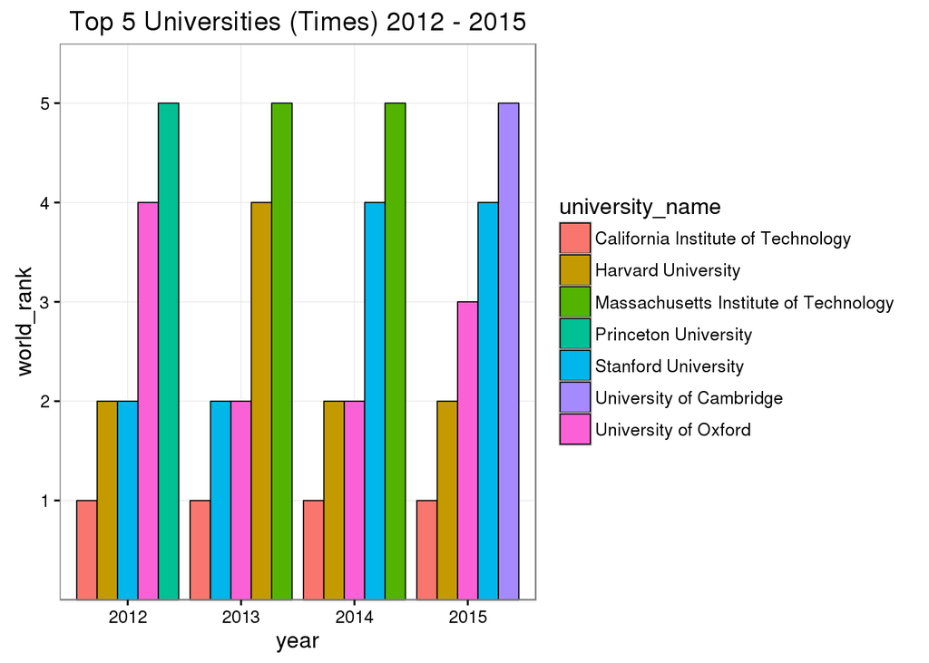

```r
# Load the ggplot2 library
library(ggplot2)

# Extract the top 5 universities from each report
times_top_5 <- filter(times_ranking, world_rank %in% c("1":"5"))
shanghai_top_5 <- filter(shanghai_ranking, world_rank %in% c("1":"5"))
cwur_top_5 <- filter(cwur_ranking, world_rank %in% c("1":"5"))

# Graph the results
ggplot(data = times_top_5, aes(x=year, y=world_rank, fill = university_name)) +
  geom_bar(colour="black", stat="identity", position = position_dodge(), size = .3) + theme_bw() + ggtitle("Top 5 Universities (Times) 2012 - 2015")
```

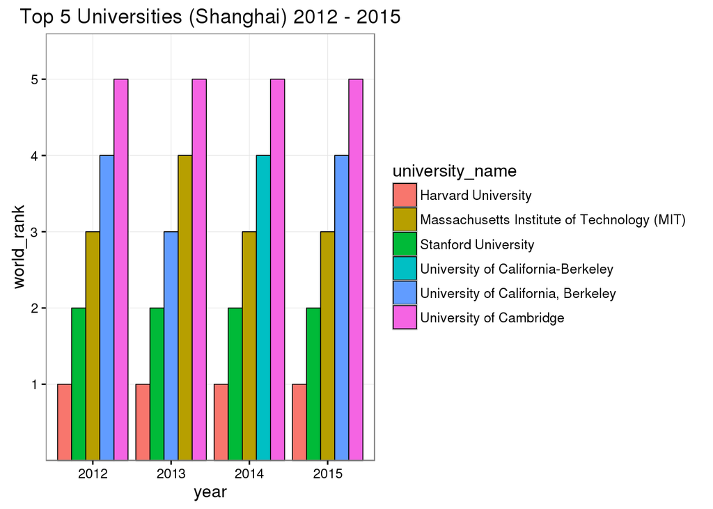

```r
ggplot(data = shanghai_top_5, aes(x=year, y=world_rank, fill = university_name)) +
  geom_bar(colour="black", stat="identity", position = position_dodge(), size = .3) + theme_bw() + ggtitle("Top 5 Universities (Shanghai) 2012 - 2015")
```

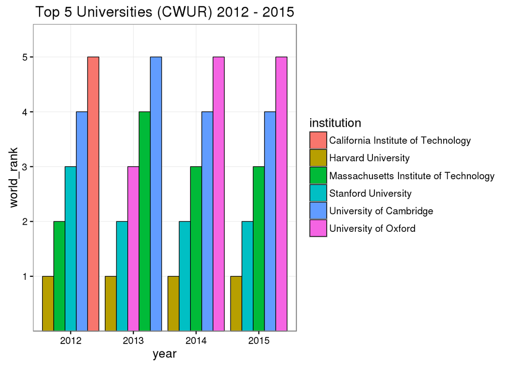

```r
ggplot(data = cwur_top_5, aes(x=year, y=world_rank, fill = institution)) +
  geom_bar(colour="black", stat="identity", position = position_dodge(), size = .3) + theme_bw() + ggtitle("Top 5 Universities (CWUR) 2012 - 2015")
```

An interesting observation is made by looking at each chart in that an institution that is ranked #1 maintains its ranking over time even though there appears to be variability in the rankings for the other universities.

```r
summary(cwur_top_5)
```

```
##    world_rank                                institution   year
##  1      :4    Harvard University                   :4    2012:5
##  2      :4    Massachusetts Institute of Technology:4    2013:5
##  3      :4    Stanford University                  :4    2014:5
##  4      :4    University of Cambridge              :4    2015:5
##  5      :4    University of Oxford                 :3
##  6      :0    California Institute of Technology   :1
##  (Other):0    (Other)                              :0
```